# LifesavR Cheatsheet (Introduction to R course)

Ben Whalley

> This page is intended as a quick reference when helping students with their data handling and analysis.

> Included on this page are short examples of everything we teach students in the LifeSavR introductory/revision course.

# Basic R statements

```r
# assign the current year to a variable
current_year <- 2021

# print the variable we created
# (it should display below the chunk, or in the console pane)
current_year
```

```
## [1] 2021
```

```r
# do a calculation to create a new variable from an existing one
next_year <- current_year + 1

next_year
```

```
## [1] 2022
```

```r
# multiply two numbers
2 * 221
```

```
## [1] 442
```

# Loading packages

These are the packages used in this cheatsheet (and the lifesavR course:

```r
library(tidyverse)
library(psydata)
library(BayesFactor)
library(corrr)
```

# Looking at data

Show only the first 6 rows of the `fuel` data

```r
head(fuel)
```

```
##    mpg cyl engine_size power weight gear automatic
## 1 21.0   6        2620   110   1188    4      TRUE
## 2 21.0   6        2620   110   1304    4      TRUE
## 3 22.8   4        1770    93   1052    4      TRUE
## 4 21.4   6        4230   110   1458    3     FALSE
## 5 18.7   8        5900   175   1560    3     FALSE
## 6 18.1   6        3690   105   1569    3     FALSE
```

Shows a list of columns in the `development` dataset plus the first few datapoints (as many as will fit)

```r
glimpse(development)
```

```
## Rows: 1,704
## Columns: 6
## $ country         <fct> Afghanistan, Afghanistan, Afghanistan, Afghanistan, A…
## $ continent       <fct> Asia, Asia, Asia, Asia, Asia, Asia, Asia, Asia, Asia,…
## $ year            <int> 1952, 1957, 1962, 1967, 1972, 1977, 1982, 1987, 1992,…
## $ life_expectancy <dbl> 28.801, 30.332, 31.997, 34.020, 36.088, 38.438, 39.85…
## $ population      <int> 8425333, 9240934, 10267083, 11537966, 13079460, 14880…
## $ gdp_per_capita  <dbl> 779.4453, 820.8530, 853.1007, 836.1971, 739.9811, 786…
```

# Filtering datasets

The `filter()` function selects rows from a dataset:

```r
# filter on a categorical variable
# == means 'match exactly'
development %>%
  filter(country == "Kenya")

# this doesn't match any rows because the data spells Kenya with a capital 'K'
development %>%
  filter(country == "kenya")

# filtering on a numeric variable
development %>% filter(year > 2000)


# combining multiple filters makes things more specific
development %>%
  filter(country == "Kenya") %>%
  filter(year > 2000)

# assign filtered data to a new variable for re-use later on
# if you don't store the data, it is displayed but then lost
development.europe <- development %>%
  filter(continent == "Europe") %>%
  filter(year > 1980)

# show the stored subset
development.europe

# make a plot with the subset
development.europe %>%
    ggplot(aes(gdp_per_capita, life_expectancy)) +
  geom_point()
```

# Frequencies

```r
# this gives us the total number of rows
earnings %>% count()
```

```
##      n
## 1 4483
```

```r
# numbers of men and women
earnings %>%
  count(gender)
```

```
##   gender    n
## 1 female 2130
## 2   male 2353
```

```r
# We can do arithmetic on these numbers
# calculate percentage
2353 / 4483 * 100
```

```
## [1] 52.48717
```

```r
# counts for multiple subgroups
earnings %>%
  count(job, gender)
```

```
##       job gender    n
## 1 charity female  210
## 2 charity   male  116
## 3   nopay female    2
## 4   nopay   male    1
## 5 private female 1507
## 6 private   male 1940
## 7  public female  411
## 8  public   male  296
```

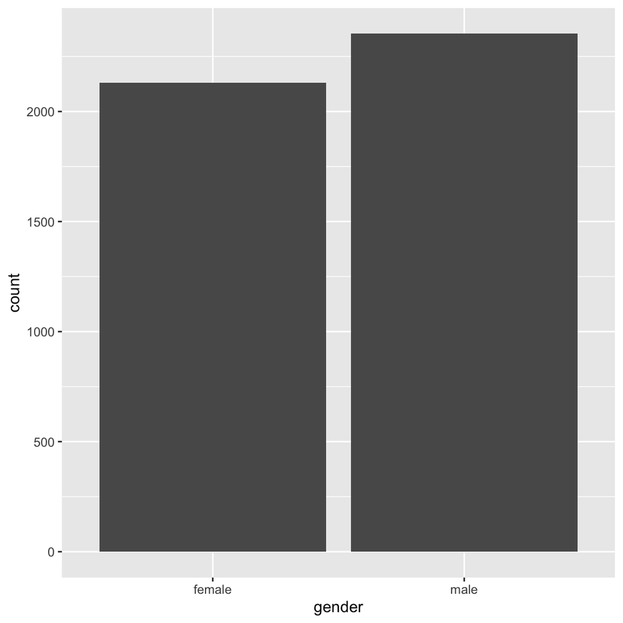

```r
# making a frwquency plot
earnings %>%
  ggplot(aes(gender)) +
  stat_count()
```

# Summarise

```r
# use function mean() to summarise mpg column
# the result is a data.frame with a single column named 'mean_mpg'
fuel %>%
  summarise(mean_mpg = mean(mpg))

# if you omit the column name, the summarised column is named after the summary function
# this produces column names which can be awkward to process later in a pipeline
# for example:
fuel %>%
  summarise(mean(mpg))

# median mpg (rather than mean)
fuel %>%
  summarise(median_mpg = median(mpg))

# standard deviation
fuel %>%
  summarise(sd_mpg = sd(mpg))

# summarise two columns at once
# the mean and sd functions are separated with a comma
# the resulting data frame is stored in a variable called fuel_summary
fuel_summary <- fuel %>%
  summarise(m = mean(mpg), sd = sd(mpg))

# see the stored summary
fuel_summary

# remember, this summary is still a new dataset; you could do more processing on it in extra steps if needed

# combining filter() and summarise()
development %>%
  filter(continent=="Asia") %>%
  summarise(Average_life_expectancy = mean(life_expectancy))
```

# Group by

```r
# calculate mean weight loss in each group in a laborious way
funimagery %>%
  filter(intervention=="MI") %>%
  summarise(mean(weight_lost_end_trt))

funimagery %>%
  filter(intervention=="FIT") %>%
  summarise(mean(weight_lost_end_trt))


# use group_by to split the data and summarise each group
funimagery %>%
  group_by(intervention) %>%
  summarise(mean(weight_lost_end_trt))
```

```r
# example of grouping by two columns at once
funimagery %>%
  group_by(gender, intervention) %>%
  summarise(mean(weight_lost_end_trt))
```

```
## # A tibble: 4 x 3
## # Groups:   gender [2]
##   gender intervention `mean(weight_lost_end_trt)`
##   <chr>  <fct>                              <dbl>
## 1 f      MI                                 -1.2
## 2 f      FIT                                -5.56
## 3 m      MI                                 -1.37
## 4 m      FIT                                -3.84
```

Calculate the mean and SD in one go

```r
funimagery %>%
  group_by(intervention) %>%
  summarise(
    mean(weight_lost_end_trt),
    sd(weight_lost_end_trt)
  )
```

```
## # A tibble: 2 x 3
##   intervention `mean(weight_lost_end_trt)` `sd(weight_lost_end_trt)`
##   <fct>                              <dbl>                     <dbl>
## 1 MI                                 -1.25                      2.09
## 2 FIT                                -5.09                      4.18
```

Give your new summary columns a name (this is good practice)

```r
funimagery %>%
  group_by(intervention) %>%
  summarise(
    mean_weight_lost_end_trt = mean(weight_lost_end_trt),
    sd_weight_lost_end_trt = sd(weight_lost_end_trt)
  )
```

```
## # A tibble: 2 x 3
##   intervention mean_weight_lost_end_trt sd_weight_lost_end_trt
##   <fct>                           <dbl>                  <dbl>
## 1 MI                              -1.25                   2.09
## 2 FIT                             -5.09                   4.18
```

# Boxplot

Boxplots show the interquartile range (IQR) as the height of the box.

The IQR is the range which includes 50% of the data points

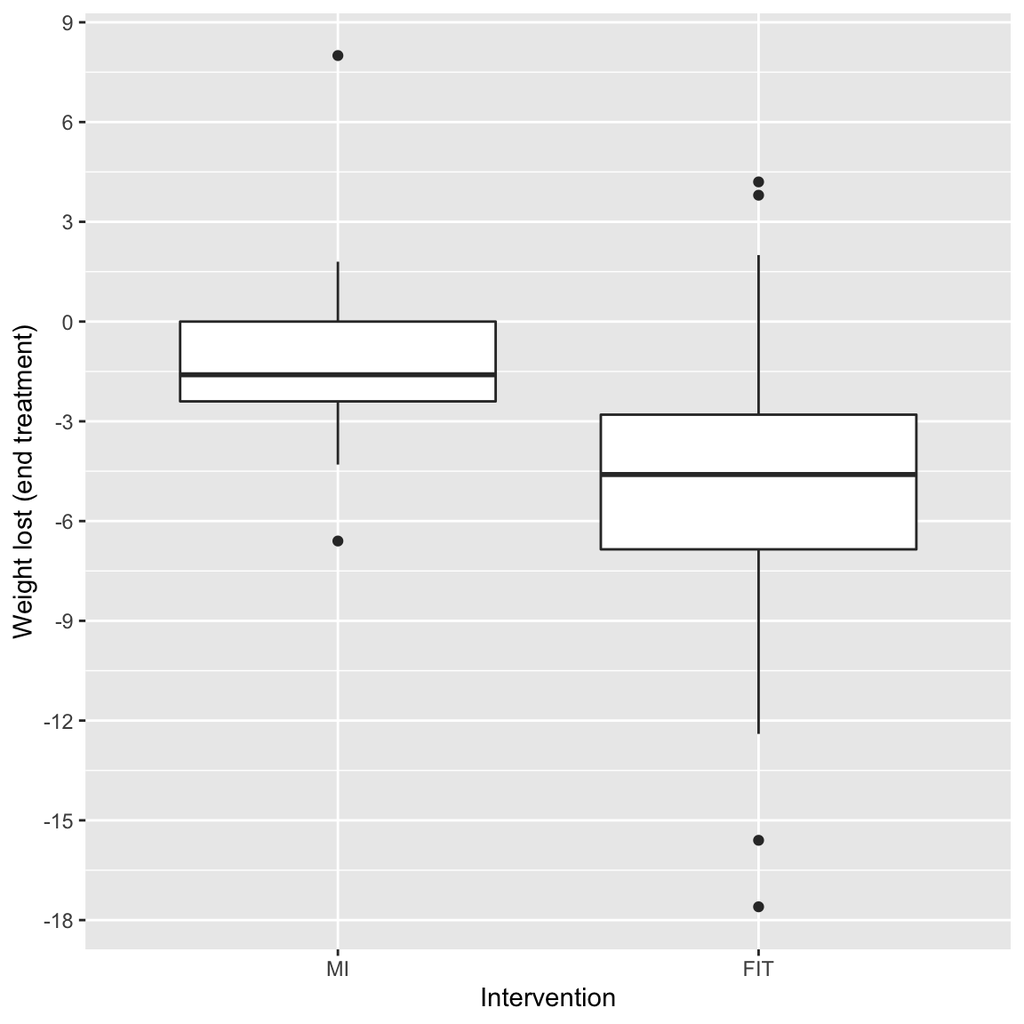

```r
funimagery %>%
  ggplot(aes(intervention, weight_lost_end_trt)) +
  geom_boxplot() +
  scale_y_continuous(n.breaks = 10) + # this extra code just adds more marks on the y-axis
  labs(x = "Intervention", y="Weight lost (end treatment)")
```

# Scatter plot

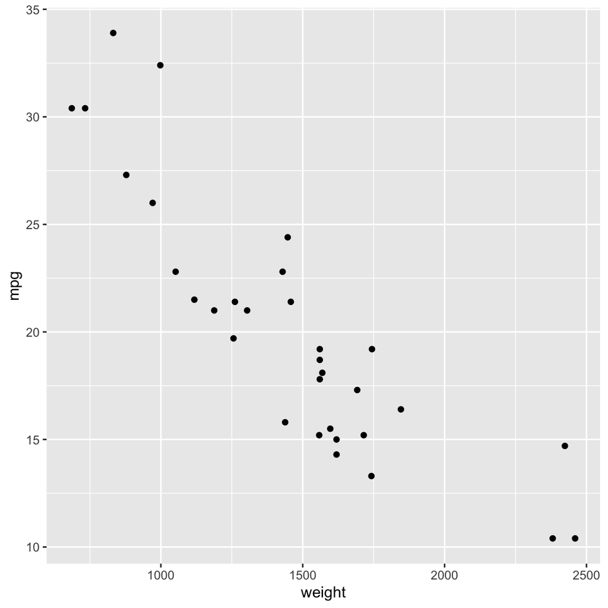

```r
fuel %>%
  ggplot(aes(x=weight, y=mpg)) + # selects the columns to use
    geom_point()                 # adds the points to the plot
```

# Correlation (and Bayes Factor)

Load the `corrr` package (see above):

```r
# select weight at baseline and follow-up in the funimagery study
# and correlate them
funimagery %>%
  select(kg1, kg2, kg3) %>%
  correlate()
```

```
##
## Correlation method: 'pearson'
## Missing treated using: 'pairwise.complete.obs'
```

```
## # A tibble: 3 x 4
##   term     kg1    kg2    kg3
##   <chr>  <dbl>  <dbl>  <dbl>
## 1 kg1   NA      0.969  0.934
## 2 kg2    0.969 NA      0.969
## 3 kg3    0.934  0.969 NA
```

```r
# use `with()` to tell `correlationBF` which dataset to use
with(funimagery,  correlationBF(kg1, kg3))
```

```
## Bayes factor analysis
## --------------
## [1] Alt., r=0.333 : 8.261128e+45 ±0%
##
## Against denominator:
##   Null, rho = 0
## ---
## Bayes factor type: BFcorrelation, Jeffreys-beta*
```

Remember to ignore the part which reads `r=0.333`. The large number after that is the Bayes Factor in favour of the correlation.

# Loading CSV data

Load CSV data from a local file (in the same directory as your `.Rmd` file… remember to upload it to the server):

```r
shootings <- read_csv("shootings.csv")
```

Load CSV data from a URL (over the web):

```r
shootings <- read_csv("https://raw.githubusercontent.com/benwhalley/psydata/main/data-raw/shootings.csv")
```